# DengAI Data Prep & Exploratory Data Analysis

Paul Y

01/03/2020

```r
knitr::opts_chunk$set(echo = TRUE)
# setwd("G:/My Drive/CAPSTONE/working")
library(dplyr)
library(tidyverse)
library(data.table)
library(ggcorrplot)
library(DataExplorer)
library(corrplot)
library(RColorBrewer)
library(devtools)
library(readr)
library(rstatix)
library(plotly)
library(ggplot2)
library(zoo)
library(scales)   # to access breaks/formatting functions
library(gridExtra) # for arranging plots
library(Hmisc)
library(pastecs)
```

## **Part 1: Data cleaning & Initial Analysis**

```r
dengue_train <- read.csv("dengue_features_train.csv", header = T, stringsAsFactors = F)
dengue_train_labels <- read.csv("dengue_labels_train.csv", header = T, stringsAsFactors = F)
dengue_test <- read.csv("dengue_features_test.csv", header = T, stringsAsFactors = F)
```

Merge the train & train_labels together. Create a null column total_cases in the testing data.

```r
dengue_train_merge <- merge(dengue_train, dengue_train_labels, by=c("city","year", "weekofyear"), all = TRUE)
dengue_test[,"total_cases"] <- NA
```

Get a quick introduction of our datasets

```r
t(introduce(dengue_train_merge)) # Training Set
```

```
##                        [,1]
## rows                   1456
## columns                  25
## discrete_columns          2
## continuous_columns       23
## all_missing_columns       0
## total_missing_values    548
## complete_rows          1199
## total_observations    36400
## memory_usage         347424
```

```r
t(introduce(dengue_test)) # Test Set
```

```
##                        [,1]
## rows                    416
## columns                  25
## discrete_columns          2
## continuous_columns       22
## all_missing_columns       1
## total_missing_values    535
## complete_rows             0
## total_observations    10400
## memory_usage         101984
```

```r
as.data.frame(sapply(dengue_train_merge, class))
```

```
##                                       sapply(dengue_train_merge, class)
## city                                                          character
## year                                                            integer
## weekofyear                                                      integer
## week_start_date                                               character
## ndvi_ne                                                         numeric
## ndvi_nw                                                         numeric
## ndvi_se                                                         numeric
## ndvi_sw                                                         numeric
## precipitation_amt_mm                                            numeric
## reanalysis_air_temp_k                                           numeric
## reanalysis_avg_temp_k                                           numeric
## reanalysis_dew_point_temp_k                                     numeric
## reanalysis_max_air_temp_k                                       numeric
## reanalysis_min_air_temp_k                                       numeric
## reanalysis_precip_amt_kg_per_m2                                 numeric
## reanalysis_relative_humidity_percent                            numeric
## reanalysis_sat_precip_amt_mm                                    numeric
## reanalysis_specific_humidity_g_per_kg                           numeric
## reanalysis_tdtr_k                                               numeric
## station_avg_temp_c                                              numeric
## station_diur_temp_rng_c                                         numeric
## station_max_temp_c                                              numeric
## station_min_temp_c                                              numeric
## station_precip_mm                                               numeric
## total_cases                                                     integer
```

```r
as.data.frame(sapply(dengue_test, class))
```

```
##                                       sapply(dengue_test, class)
## city                                                   character
## year                                                     integer
## weekofyear                                               integer
## week_start_date                                        character
## ndvi_ne                                                  numeric
## ndvi_nw                                                  numeric
## ndvi_se                                                  numeric
## ndvi_sw                                                  numeric
## precipitation_amt_mm                                     numeric
## reanalysis_air_temp_k                                    numeric
## reanalysis_avg_temp_k                                    numeric
## reanalysis_dew_point_temp_k                              numeric
## reanalysis_max_air_temp_k                                numeric
## reanalysis_min_air_temp_k                                numeric
## reanalysis_precip_amt_kg_per_m2                          numeric
## reanalysis_relative_humidity_percent                     numeric
## reanalysis_sat_precip_amt_mm                             numeric
## reanalysis_specific_humidity_g_per_kg                    numeric
## reanalysis_tdtr_k                                        numeric
## station_avg_temp_c                                       numeric
## station_diur_temp_rng_c                                  numeric
## station_max_temp_c                                       numeric
## station_min_temp_c                                       numeric
## station_precip_mm                                        numeric
## total_cases                                              logical
```

```r
dengue_train_merge <- dengue_train_merge[!sapply(dengue_train_merge, function(x) all(x == ""))]
train_dim <- c(nrow(dengue_train_merge), ncol(dengue_train_merge))
test_dim <- c(nrow(dengue_test), ncol(dengue_test))
train_dim
```

```
## [1] 1456   25
```

```r
test_dim
```

```
## [1] 416  25
```

### Time for some Data Manipulation

Convert week_start_date to date class. Create columns for year, day, day of the year, month.

```r
dengue_train_merge$week_start_date <- as.Date(dengue_train_merge$week_start_date)
dengue_test$week_start_date <- as.Date(dengue_test$week_start_date)

dengue_train_merge$year <- format(dengue_train_merge$week_start_date, "%Y")
dengue_train_merge$month <- format(dengue_train_merge$week_start_date, "%b")
dengue_train_merge$day <- format(dengue_train_merge$week_start_date, "%d")
dengue_train_merge$day_of_year <- format(dengue_train_merge$week_start_date, "%j")

dengue_test$year <- format(dengue_test$week_start_date, "%Y")
dengue_test$month <- format(dengue_test$week_start_date, "%b")
dengue_test$day <- format(dengue_test$week_start_date, "%d")
dengue_test$day_of_year <- format(dengue_test$week_start_date, "%j")
```

Check if there are actually 52 weeks in each year

```r
dengue_train_merge[which(dengue_train_merge$weekofyear == "53"), 1:4]
```

```
##      city year weekofyear week_start_date
## 282    iq 2005         53      2005-01-01
## 516    iq 2010         53      2010-01-01
## 707    sj 1993         53      1993-01-01
## 1019   sj 1999         53      1999-01-01
## 1331   sj 2005         53      2005-01-01
```

```r
dengue_test[which(dengue_test$weekofyear == "53"), 1:4]
```

```
##    city year weekofyear week_start_date
## 88   sj 2010         53      2010-01-01
```

Upon viewing the data above, we have that the 53rd week of each year is actually the 1st day of each year. Let’s try to change these to the 1st week of their respective years to remain consistent with the data.

```r
dengue_train_merge$weekofyear[dengue_train_merge$weekofyear == "53"] <- "1"
dengue_test$weekofyear[dengue_test$weekofyear == "53"] <- "1"
```

The following columns are in Kelvin (K): reanalysis_air_temp_k, reanalysis_avg_temp_k, reanalysis_dew_point_temp_k, reanalysis_max_air_temp_k, reanalysis_min_air_temp_k, and reanalysis_tdtr_k. Let’s convert them to Centigrade (°C)

```r
for (i in c(10:14, 19)) {dengue_train_merge[,i] <- dengue_train_merge[,i] - 273.15}
for (i in c(10:14, 19)) {dengue_test[,i] <- dengue_test[,i] - 273.15}
```

Let’s now rename these columns using the tidyverse package

```r
dengue_train_merge <- dengue_train_merge %>%
  rename(
    reanalysis_air_temp_c = reanalysis_air_temp_k,
    reanalysis_avg_temp_c = reanalysis_avg_temp_k,
    reanalysis_dew_point_temp_c = reanalysis_dew_point_temp_k,
    reanalysis_max_air_temp_c = reanalysis_max_air_temp_k,
    reanalysis_min_air_temp_c = reanalysis_min_air_temp_k,
    reanalysis_tdtr_c = reanalysis_tdtr_k,
    )
head(dengue_train_merge, n=2)
```

```
##   city year weekofyear week_start_date   ndvi_ne   ndvi_nw   ndvi_se   ndvi_sw
## 1   iq 2000         26      2000-07-01 0.1928857 0.1322571 0.3408857 0.2472000
## 2   iq 2000         27      2000-07-08 0.2168333 0.2761000 0.2894571 0.2416571
##   precipitation_amt_mm reanalysis_air_temp_c reanalysis_avg_temp_c
## 1                25.41              23.59000              25.30000
## 2                60.61              23.48429              25.27857
##   reanalysis_dew_point_temp_c reanalysis_max_air_temp_c
## 1                    22.03429                     34.15
## 2                    22.20857                     33.45
##   reanalysis_min_air_temp_c reanalysis_precip_amt_kg_per_m2
## 1                     19.95                           43.19
## 2                     17.95                           46.00
##   reanalysis_relative_humidity_percent reanalysis_sat_precip_amt_mm
## 1                             92.41857                        25.41
## 2                             93.58143                        60.61
##   reanalysis_specific_humidity_g_per_kg reanalysis_tdtr_c station_avg_temp_c
## 1                              16.65143         -264.2214               26.4
## 2                              16.86286         -262.8357               26.9
##   station_diur_temp_rng_c station_max_temp_c station_min_temp_c
## 1                10.77500               32.5               20.7
## 2                11.56667               34.0               20.8
##   station_precip_mm total_cases month day day_of_year
## 1               3.0           0   Jul  01         183
## 2              55.6           0   Jul  08         190
```

```r
dengue_test <- dengue_test %>%
  rename(
    reanalysis_air_temp_c = reanalysis_air_temp_k,
    reanalysis_avg_temp_c = reanalysis_avg_temp_k,
    reanalysis_dew_point_temp_c = reanalysis_dew_point_temp_k,
    reanalysis_max_air_temp_c = reanalysis_max_air_temp_k,
    reanalysis_min_air_temp_c = reanalysis_min_air_temp_k,
    reanalysis_tdtr_c = reanalysis_tdtr_k,
    )
```

Determine number of NAs & Nulls in each dataframe

```r
sum_na <- c(sum(is.na(dengue_train_merge)), sum(is.na(dengue_test)))
sum_null <- c(sum(is.null(dengue_train_merge)), sum(is.null(dengue_test)))
sum_na
```

```
## [1] 548 535
```

```r
sum_null
```

```
## [1] 0 0
```

Our train data has 548 missing values; test has 535 missing values.

Check which columns have NAs in them.

```r
sapply(dengue_train_merge, function(x) sum(is.na(x)))
```

```
##                                  city                                  year
##                                     0                                     0
##                            weekofyear                       week_start_date
##                                     0                                     0
##                               ndvi_ne                               ndvi_nw
##                                   194                                    52
##                               ndvi_se                               ndvi_sw
##                                    22                                    22
##                  precipitation_amt_mm                 reanalysis_air_temp_c
##                                    13                                    10
##                 reanalysis_avg_temp_c           reanalysis_dew_point_temp_c
##                                    10                                    10
##             reanalysis_max_air_temp_c             reanalysis_min_air_temp_c
##                                    10                                    10
##       reanalysis_precip_amt_kg_per_m2  reanalysis_relative_humidity_percent
##                                    10                                    10
##          reanalysis_sat_precip_amt_mm reanalysis_specific_humidity_g_per_kg
##                                    13                                    10
##                     reanalysis_tdtr_c                    station_avg_temp_c
##                                    10                                    43
##               station_diur_temp_rng_c                    station_max_temp_c
##                                    43                                    20
##                    station_min_temp_c                     station_precip_mm
##                                    14                                    22
##                           total_cases                                 month
##                                     0                                     0
##                                   day                           day_of_year
##                                     0                                     0
```

```r
sum(is.na(dengue_train_merge$total_cases))
```

```
## [1] 0
```

```r
sapply(dengue_test, function(x) sum(is.na(x)))
```

```
##                                  city                                  year
##                                     0                                     0
##                            weekofyear                       week_start_date
##                                     0                                     0
##                               ndvi_ne                               ndvi_nw
##                                    43                                    11
##                               ndvi_se                               ndvi_sw
##                                     1                                     1
##                  precipitation_amt_mm                 reanalysis_air_temp_c
##                                     2                                     2
##                 reanalysis_avg_temp_c           reanalysis_dew_point_temp_c
##                                     2                                     2
##             reanalysis_max_air_temp_c             reanalysis_min_air_temp_c
##                                     2                                     2
##       reanalysis_precip_amt_kg_per_m2  reanalysis_relative_humidity_percent
##                                     2                                     2
##          reanalysis_sat_precip_amt_mm reanalysis_specific_humidity_g_per_kg
##                                     2                                     2
##                     reanalysis_tdtr_c                    station_avg_temp_c
##                                     2                                    12
##               station_diur_temp_rng_c                    station_max_temp_c
##                                    12                                     3
##                    station_min_temp_c                     station_precip_mm
##                                     9                                     5
##                           total_cases                                 month
##                                   416                                     0
##                                   day                           day_of_year
##                                     0                                     0
```

In the train data, ndvi columns have the most missing values. The missing values in the climate factors range from 10-40. There are no missing values in total_cases. The column total_cases in the test set has missing columns because that is the variable we are trying to predict.

Determine if there are rows where majority of the climate features are missing. Drop rows with 50% or more NA, just in our training set.

```r
dengue_train_merge <- dengue_train_merge[which(rowMeans(!is.na(dengue_train_merge)) >= 0.5), ]
```

Simply impute the rest of the null rows of the climate features (training set) with the previous non-NA value using the function na.locf()

```r
for (i in c(5:24)) {dengue_train_merge[,i] <- na.locf(dengue_train_merge[,i])}
sapply(dengue_train_merge, function(x) sum(is.na(x)))
```

```
##                                  city                                  year
##                                     0                                     0
##                            weekofyear                       week_start_date
##                                     0                                     0
##                               ndvi_ne                               ndvi_nw
##                                     0                                     0
##                               ndvi_se                               ndvi_sw
##                                     0                                     0
##                  precipitation_amt_mm                 reanalysis_air_temp_c
##                                     0                                     0
##                 reanalysis_avg_temp_c           reanalysis_dew_point_temp_c
##                                     0                                     0
##             reanalysis_max_air_temp_c             reanalysis_min_air_temp_c
##                                     0                                     0
##       reanalysis_precip_amt_kg_per_m2  reanalysis_relative_humidity_percent
##                                     0                                     0
##          reanalysis_sat_precip_amt_mm reanalysis_specific_humidity_g_per_kg
##                                     0                                     0
##                     reanalysis_tdtr_c                    station_avg_temp_c
##                                     0                                     0
##               station_diur_temp_rng_c                    station_max_temp_c
##                                     0                                     0
##                    station_min_temp_c                     station_precip_mm
##                                     0                                     0
##                           total_cases                                 month
##                                     0                                     0
##                                   day                           day_of_year
##                                     0                                     0
```

Let us subset the training data by city

```r
dengue_iq <- dengue_train_merge %>% filter(city == "iq")
dengue_sj <- dengue_train_merge %>% filter(city == "sj")
head(dengue_iq, n=2)
```

```
##   city year weekofyear week_start_date   ndvi_ne   ndvi_nw   ndvi_se   ndvi_sw
## 1   iq 2000         26      2000-07-01 0.1928857 0.1322571 0.3408857 0.2472000
## 2   iq 2000         27      2000-07-08 0.2168333 0.2761000 0.2894571 0.2416571
##   precipitation_amt_mm reanalysis_air_temp_c reanalysis_avg_temp_c
## 1                25.41              23.59000              25.30000
## 2                60.61              23.48429              25.27857
##   reanalysis_dew_point_temp_c reanalysis_max_air_temp_c
## 1                    22.03429                     34.15
## 2                    22.20857                     33.45
##   reanalysis_min_air_temp_c reanalysis_precip_amt_kg_per_m2
## 1                     19.95                           43.19
## 2                     17.95                           46.00
##   reanalysis_relative_humidity_percent reanalysis_sat_precip_amt_mm
## 1                             92.41857                        25.41
## 2                             93.58143                        60.61
##   reanalysis_specific_humidity_g_per_kg reanalysis_tdtr_c station_avg_temp_c
## 1                              16.65143         -264.2214               26.4
## 2                              16.86286         -262.8357               26.9
##   station_diur_temp_rng_c station_max_temp_c station_min_temp_c
## 1                10.77500               32.5               20.7
## 2                11.56667               34.0               20.8
##   station_precip_mm total_cases month day day_of_year
## 1               3.0           0   Jul  01         183
## 2              55.6           0   Jul  08         190
```

```r
head(dengue_sj, n=2)
```

```
##   city year weekofyear week_start_date ndvi_ne  ndvi_nw   ndvi_se   ndvi_sw
## 1   sj 1990         18      1990-04-30  0.1226 0.103725 0.1984833 0.1776167
## 2   sj 1990         19      1990-05-07  0.1699 0.142175 0.1623571 0.1554857
##   precipitation_amt_mm reanalysis_air_temp_c reanalysis_avg_temp_c
## 1                12.42              24.42286              24.59286
## 2                22.82              25.06143              25.29286
##   reanalysis_dew_point_temp_c reanalysis_max_air_temp_c
## 1                    19.26429                     26.65
## 2                    20.80143                     27.75
##   reanalysis_min_air_temp_c reanalysis_precip_amt_kg_per_m2
## 1                     22.75                           32.00
## 2                     23.25                           17.94
##   reanalysis_relative_humidity_percent reanalysis_sat_precip_amt_mm
## 1                             73.36571                        12.42
## 2                             77.36857                        22.82
##   reanalysis_specific_humidity_g_per_kg reanalysis_tdtr_c station_avg_temp_c
## 1                              14.01286         -270.5214           25.44286
## 2                              15.37286         -270.7786           26.71429
##   station_diur_temp_rng_c station_max_temp_c station_min_temp_c
## 1                6.900000               29.4               20.0
## 2                6.371429               31.7               22.2
##   station_precip_mm total_cases month day day_of_year
## 1              16.0           4   Apr  30         120
## 2               8.6           5   May  07         127
```

Rename datasets. Subset test set by city as well.

```r
train_df <- dengue_train_merge
train_iq <- dengue_iq
train_sj <- dengue_sj
test_df <- dengue_test
test_iq <- test_df %>% filter(city == "iq")
test_sj <- test_df %>% filter(city == "sj")
```

Write these datasets to folder for future working purposes

```r
write.csv(train_df,"train_df.csv", row.names=FALSE)
write.csv(train_iq,"train_iq.csv", row.names=FALSE)
write.csv(train_sj,"train_sj.csv", row.names=FALSE)
write.csv(test_df,"test_df.csv", row.names=FALSE)
write.csv(test_iq,"test_iq.csv", row.names=FALSE)
write.csv(test_sj,"test_sj.csv", row.names=FALSE)
```

## **Part 2: Univariate & Bivariate Analysis (EDA)**

Using the pastecs package, call the stat.desc() function, which displays important information about the standard deviation, standard error, variance, coefficient of variation, and confidence interval for mean; also includes basic information found within the summary() function.

```r
iq_stats <- subset(stat.desc(train_iq), select = c(5:25))
sj_stats <- subset(stat.desc(train_sj), select = c(5:25))
iq_stats <- t(format(iq_stats, scientific=F))
sj_stats <- t(format(sj_stats, scientific=F))
write.table(iq_stats, "iq_stats.csv",  sep = ",", row.names = T, col.names = T)
write.table(sj_stats, "sj_stats.csv", sep = ",", row.names = T, col.names = T)
iq_stats = read.csv("iq_stats.csv", header = T)
sj_stats = read.csv("sj_stats.csv", header = T)
iq_stats <- as.data.frame(iq_stats)
sj_stats <- as.data.frame(sj_stats)
```

Let’s focus on our response variable, total_cases

```r
iq_stats[c("total_cases"),]
```

```
##             nbr.val nbr.null nbr.na min max range  sum median     mean
## total_cases     516       95      0   0 116   116 3920      5 7.596899
##               SE.mean   CI.mean      var  std.dev coef.var
## total_cases 0.4753032 0.9337716 116.5712 10.79681 1.421213
```

```r
sj_stats[c("total_cases"),]
```

```
##             nbr.val nbr.null nbr.na min max range   sum median     mean
## total_cases     930        4      0   0 461   461 31734     19 34.12258
##              SE.mean  CI.mean      var  std.dev coef.var
## total_cases 1.688694 3.314097 2652.069 51.49824 1.509213
```

Let’s plot some graphics detailing climate features between the cities of San Juan & Iquitos.

Plot frequency of our target variable total_cases by year in the training, Iquitos training, and San Juan training set. There are no records of total_cases in our testing sets, and thus, we cannot create plots from test_df, test_iq, & test_sj.

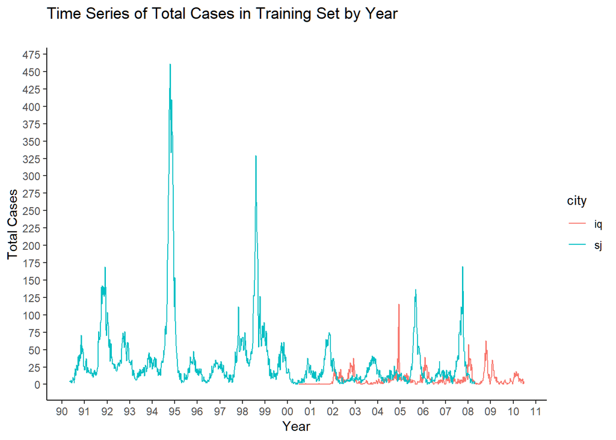

```r
cases_train_df <- ggplot(data = train_df, aes(x = week_start_date, y = total_cases, color = city)) +
  geom_line() +
  labs(x = "Year",
    y = "Total Cases",
    title = "Time Series of Total Cases in Training Set by Year",
    subtitle = "")
cases_train_df + scale_x_date(date_breaks = "1 year", date_labels = "%y") + scale_y_continuous(breaks=seq(0, 475, 25)) + theme_classic()
```

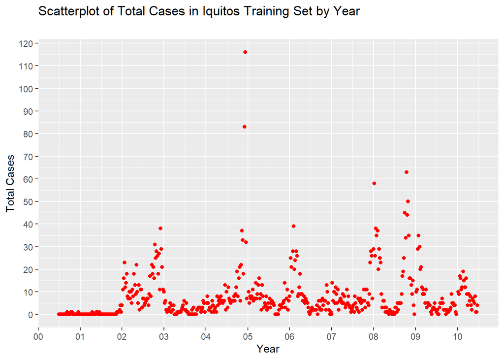

```r
cases_train_iq <- ggplot(data = train_iq, aes(x = week_start_date, y = total_cases)) +
  geom_point(color = "red") +
  labs(x = "Year",
    y = "Total Cases",
    title = "Scatterplot of Total Cases in Iquitos Training Set by Year",
    subtitle = "")
cases_train_iq + scale_x_date(date_breaks = "1 year", date_labels = "%y") + scale_y_continuous(breaks=seq(0, 200, 10))
```

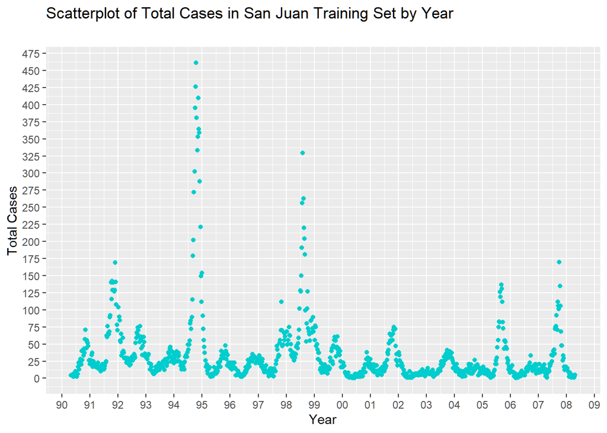

```r
cases_train_sj <- ggplot(data = train_sj, aes(x = week_start_date, y = total_cases)) +
  geom_point(color = "cyan3") +
  labs(x = "Year",
    y = "Total Cases",
    title = "Scatterplot of Total Cases in San Juan Training Set by Year",
    subtitle = "")
cases_train_sj + scale_x_date(date_breaks = "1 year", date_labels = "%y") + scale_y_continuous(breaks=seq(0, 475, 25))
```

We can try plotting a time series of one of the climate features, reanalysis_air_temp_c (the Mean Air Temperature), and try to reach a hypotheseis about our data that can support concluding statements of prediciting the number of cases in the test set.

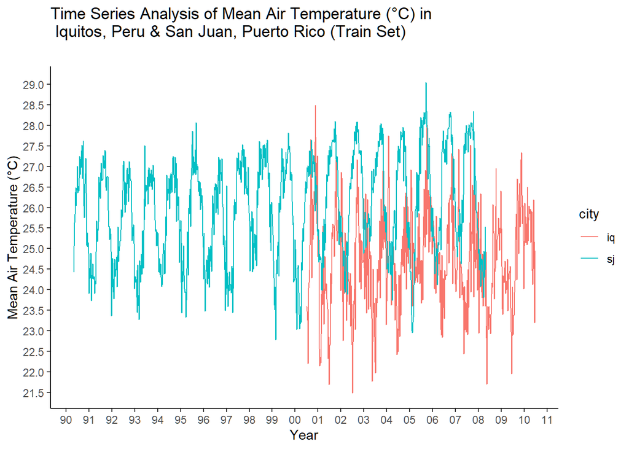

```r
airtemp_train_df <- ggplot(data = train_df, aes(x = week_start_date, y = reanalysis_air_temp_c, color = city)) +
  geom_line() +
  labs(x = "Year",
    y = "Mean Air Temperature (°C)",
    title = "Time Series Analysis of Mean Air Temperature (°C) in \n Iquitos, Peru & San Juan, Puerto Rico (Train Set)",
    subtitle = "")
airtemp_train_df + scale_x_date(date_breaks = "1 year", date_labels = "%y") + scale_y_continuous(breaks=seq(0, 30, 0.5)) + theme_classic()
```

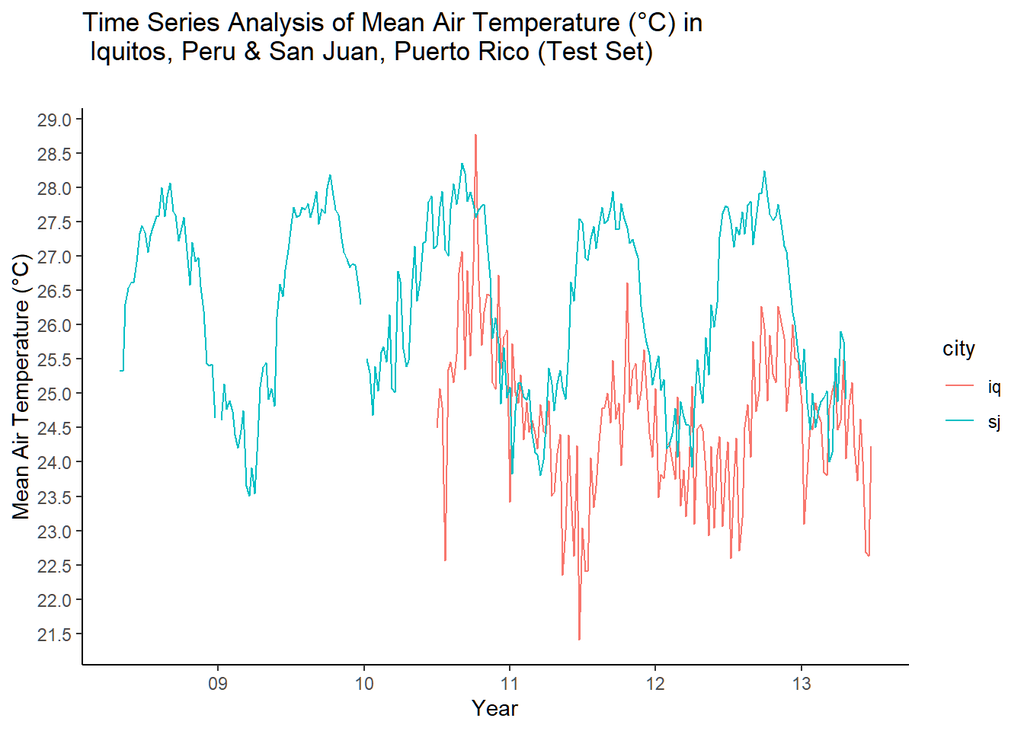

```r
airtemp_test_df <- ggplot(data = test_df, aes(x = week_start_date, y = reanalysis_air_temp_c, color = city)) +
  geom_line() +
  labs(x = "Year",
    y = "Mean Air Temperature (°C)",
    title = "Time Series Analysis of Mean Air Temperature (°C) in \n Iquitos, Peru & San Juan, Puerto Rico (Test Set)",
    subtitle = "")
airtemp_test_df + scale_x_date(date_breaks = "1 year", date_labels = "%y") + scale_y_continuous(breaks=seq(0, 30, 0.5)) + theme_classic()
```

The time series analysis of mean air temperature (°C) in the training set shows us that San Juan achieves higher air temperature compared to Iquitos.

Let’s plot a time series analysis of Mean Specific Humidity (vapour g/air kg) in train & test set.

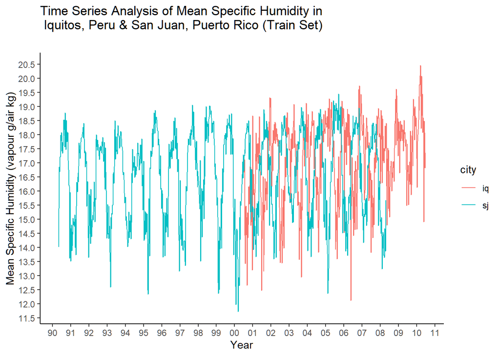

```r
hum_train_df <- ggplot(data = train_df, aes(x = week_start_date, y = reanalysis_specific_humidity_g_per_kg, color = city)) +
  geom_line() +
  labs(x = "Year",
    y = "Mean Specific Humidity (vapour g/air kg)",
    title = "Time Series Analysis of Mean Specific Humidity in \n Iquitos, Peru & San Juan, Puerto Rico (Train Set)",
    subtitle = "")
hum_train_df + scale_x_date(date_breaks = "1 year", date_labels = "%y") + scale_y_continuous(breaks=seq(0, 21, 0.5)) + theme_classic()
```

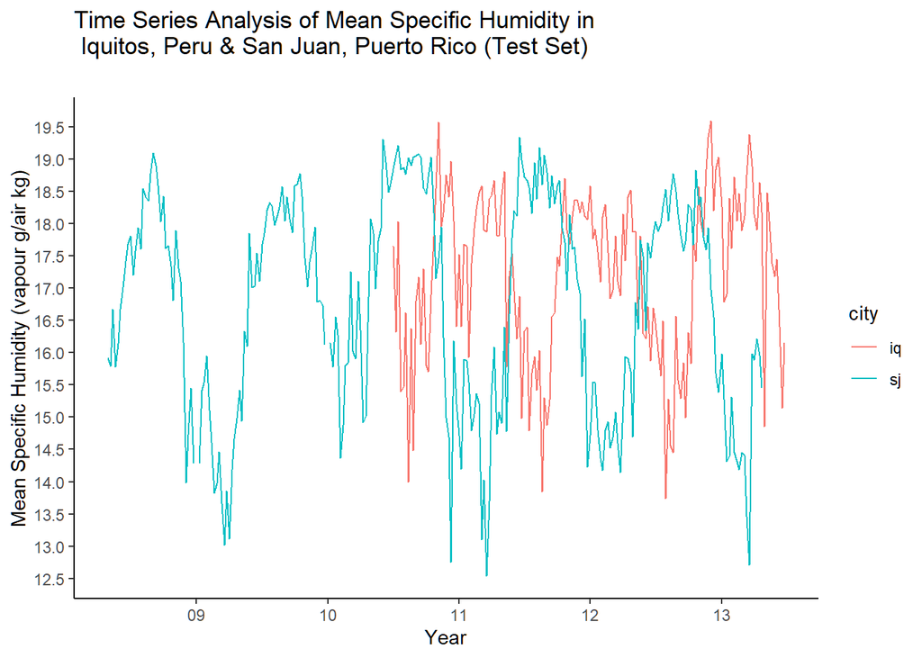

```r
hum_test_df <- ggplot(data = test_df, aes(x = week_start_date, y = reanalysis_specific_humidity_g_per_kg, color = city)) +
  geom_line() +
  labs(x = "Year",
    y = "Mean Specific Humidity (vapour g/air kg)",
    title = "Time Series Analysis of Mean Specific Humidity in \n Iquitos, Peru & San Juan, Puerto Rico (Test Set)",
    subtitle = "")
hum_test_df + scale_x_date(date_breaks = "1 year", date_labels = "%y") + scale_y_continuous(breaks=seq(0, 21, 0.5)) + theme_classic()
```

### Time for some correlation analysis

Let’s visualize the correlation matrix in our training set. Focus on the total_cases variable.

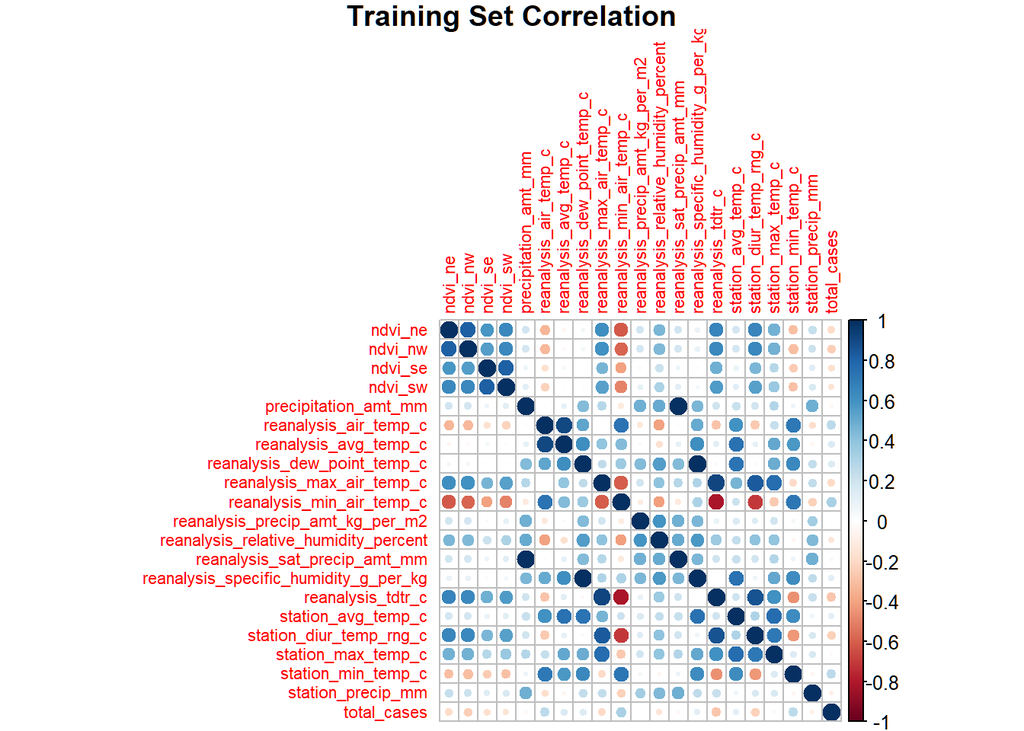

```r
cor.mat.train_df <- cor(train_df[, c(5:25)], use = "complete.obs")
corrplot(cor.mat.train_df, tl.cex = 0.7, title = "Training Set Correlation", mar=c(0,0,1,0))
```

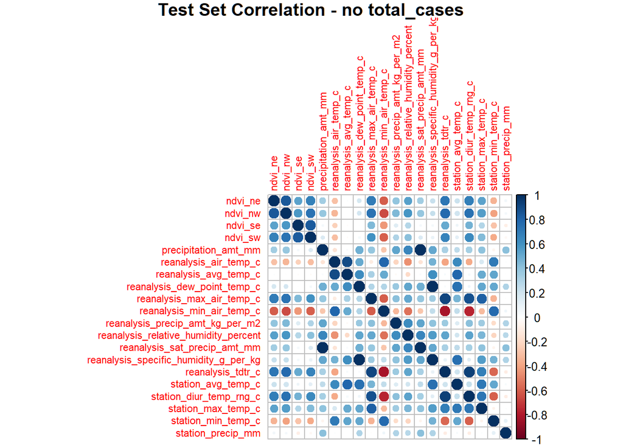

```r
cor.mat.test_df <- cor(test_df[, c(5:24)], use = "complete.obs") # Remove NAs
corrplot(cor.mat.test_df, tl.cex = 0.7, title = "Test Set Correlation - no total_cases", mar=c(0,0,1,0))
```

Correlate total_cases with climate features in the Iquitos and San Juan training sets.

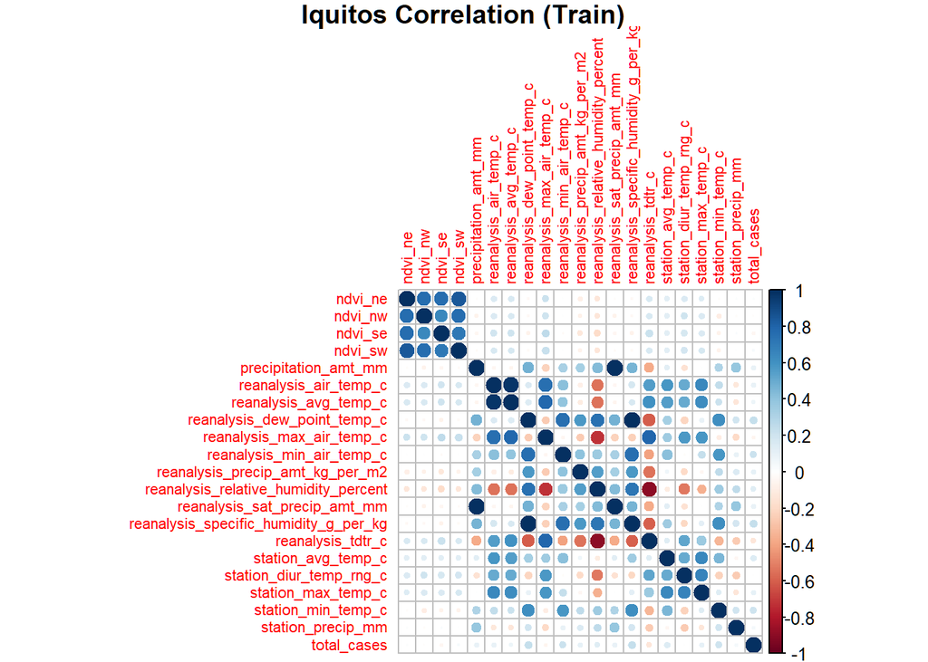

```r
cor.mat.train_iq <- cor(train_iq[, c(5:25)], use = "complete.obs")
corrplot(cor.mat.train_iq, title = "Iquitos Correlation (Train)", mar=c(0,0,1,0), tl.cex = 0.7) # Iquitos correlation
```

```r
cor.mat.train_iq.df <- as.data.frame(cor.mat.train_iq)
cor.iq <- as.data.frame(cbind(total_cases_cor_iq = cor.mat.train_iq.df$total_cases, features_iq = colnames(cor.mat.train_iq.df[,1:ncol(cor.mat.train_iq.df)]))) # determine total_cases correlation values with other climate features in Iquitos
cor.iq$total_cases_cor_iq <-as.numeric(as.character(cor.iq[,1]))
cor.iq %>%
   arrange(desc(abs(cor.iq$total_cases_cor_iq)))
```

```
##    total_cases_cor_iq                           features_iq
## 1        1.0000000000                           total_cases
## 2        0.2364760515 reanalysis_specific_humidity_g_per_kg
## 3        0.2304014131           reanalysis_dew_point_temp_c
## 4        0.2145139522             reanalysis_min_air_temp_c
## 5        0.2059312937                    station_min_temp_c
## 6        0.1463177564                    station_avg_temp_c
## 7       -0.1344245276                     reanalysis_tdtr_c
## 8        0.1300827370  reanalysis_relative_humidity_percent
## 9        0.1011714945       reanalysis_precip_amt_kg_per_m2
## 10       0.1008912593                    station_max_temp_c
## 11       0.0970977884                 reanalysis_air_temp_c
## 12       0.0901705094                  precipitation_amt_mm
## 13       0.0901705094          reanalysis_sat_precip_amt_mm
## 14       0.0798717369                 reanalysis_avg_temp_c
## 15      -0.0564735746             reanalysis_max_air_temp_c
## 16      -0.0416432269                               ndvi_se
## 17       0.0408367557                     station_precip_mm
## 18       0.0312311929                               ndvi_sw
## 19       0.0184945833                               ndvi_ne
## 20      -0.0109833701                               ndvi_nw
## 21      -0.0004559951               station_diur_temp_rng_c
```

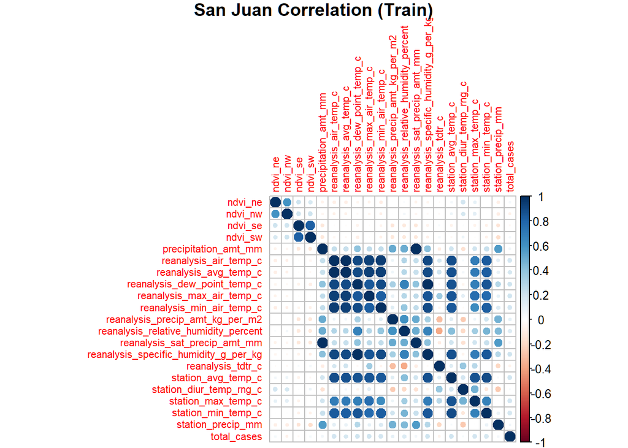

```r
cor.mat.train_sj <- cor(train_sj[, c(5:25)], use = "complete.obs")
corrplot(cor.mat.train_sj, title = "San Juan Correlation (Train)", mar=c(0,0,1,0), tl.cex = 0.7) # San Juan correlation
```

```r
cor.mat.train_sj.df <- as.data.frame(cor.mat.train_sj)
cor.sj <- as.data.frame(cbind(total_cases_cor_sj = cor.mat.train_sj.df$total_cases, features_sj = colnames(cor.mat.train_sj.df[,1:ncol(cor.mat.train_sj.df)]))) # determine total_cases correlation values with other climate features in San Juan
cor.sj$total_cases_cor_sj <-as.numeric(as.character(cor.sj[,1]))
cor.sj %>%
   arrange(desc(abs(cor.sj$total_cases_cor_sj)))
```

```
##    total_cases_cor_sj                           features_sj
## 1          1.00000000                           total_cases
## 2          0.20794741 reanalysis_specific_humidity_g_per_kg
## 3          0.20377424           reanalysis_dew_point_temp_c
## 4          0.19661656                    station_avg_temp_c
## 5          0.19453182             reanalysis_max_air_temp_c
## 6          0.18990073                    station_max_temp_c
## 7          0.18794289             reanalysis_min_air_temp_c
## 8          0.18191695                 reanalysis_air_temp_c
## 9          0.17701194                    station_min_temp_c
## 10         0.17526745                 reanalysis_avg_temp_c
## 11         0.14404470  reanalysis_relative_humidity_percent
## 12         0.10745738       reanalysis_precip_amt_kg_per_m2
## 13        -0.07738197                               ndvi_nw
## 14        -0.06759993                     reanalysis_tdtr_c
## 15         0.05957809                  precipitation_amt_mm
## 16         0.05957809          reanalysis_sat_precip_amt_mm
## 17         0.05175921                     station_precip_mm
## 18         0.04938813                               ndvi_sw
## 19         0.04370803                               ndvi_ne
## 20         0.03463007               station_diur_temp_rng_c
## 21        -0.03198680                               ndvi_se
```

We sort the total_cases correlation in Iquitos and San Juan training set by the highest absolute values. Visually, we don’t have very strong features that correlate well with total_cases.

Let’s make our analysis stronger by extracting significance levels (p-values) using package Hmisc: Harrell Miscellaneous.

```r
rcorr_iq <- rcorr(as.matrix(train_iq[, c(5:25)]))
rcorr_sj <- rcorr(as.matrix(train_sj[, c(5:25)]))
```

We will be using a function to format the correlation matrix, which displays the correlation and p-value in a neat dataframe.

```r
# ++++++++++++++++++++++++++++
# flattenCorrMatrix
# ++++++++++++++++++++++++++++
# cormat : matrix of the correlation coefficients
# pmat : matrix of the correlation p-values
flattenCorrMatrix <- function(cormat, pmat) {
  ut <- upper.tri(cormat)
  data.frame(
    row = rownames(cormat)[row(cormat)[ut]],
    column = rownames(cormat)[col(cormat)[ut]],
    cor  =(cormat)[ut],
    p = pmat[ut]
    )
}
```

Extract the p-values & correlation from both cities with target variable total_cases. We sort the dataset by ascending p-value. Features with lower p-values implies higher significance of the predictor variable in correlation with the target variable.

```r
IQ <- flattenCorrMatrix(rcorr_iq$r, rcorr_iq$P)
sub_iq <- subset(IQ , column=="total_cases")
sub_iq[order(sub_iq$p), ]# Sort Iquitos training set by ascending p-values
```

```
##                                       row      column           cor
## 204 reanalysis_specific_humidity_g_per_kg total_cases  0.2364760515
## 198           reanalysis_dew_point_temp_c total_cases  0.2304014131
## 200             reanalysis_min_air_temp_c total_cases  0.2145139522
## 209                    station_min_temp_c total_cases  0.2059312937
## 206                    station_avg_temp_c total_cases  0.1463177564
## 205                     reanalysis_tdtr_c total_cases -0.1344245276
## 202  reanalysis_relative_humidity_percent total_cases  0.1300827370
## 201       reanalysis_precip_amt_kg_per_m2 total_cases  0.1011714945
## 208                    station_max_temp_c total_cases  0.1008912593
## 196                 reanalysis_air_temp_c total_cases  0.0970977884
## 195                  precipitation_amt_mm total_cases  0.0901705094
## 203          reanalysis_sat_precip_amt_mm total_cases  0.0901705094
## 197                 reanalysis_avg_temp_c total_cases  0.0798717369
## 199             reanalysis_max_air_temp_c total_cases -0.0564735746
```

[output cut: 27 more lines]

```r
SJ <- flattenCorrMatrix(rcorr_sj$r, rcorr_sj$P)
sub_sj <- subset(SJ , column=="total_cases")
sub_sj[order(sub_sj$p), ] # Sort San Juan training set by ascending p-values
```

```
##                                       row      column         cor            p
## 204 reanalysis_specific_humidity_g_per_kg total_cases  0.20794741 1.522173e-10
## 198           reanalysis_dew_point_temp_c total_cases  0.20377424 3.568019e-10
## 206                    station_avg_temp_c total_cases  0.19661656 1.475172e-09
## 199             reanalysis_max_air_temp_c total_cases  0.19453182 2.208508e-09
## 208                    station_max_temp_c total_cases  0.18990073 5.327848e-09
## 200             reanalysis_min_air_temp_c total_cases  0.18794289 7.680723e-09
## 196                 reanalysis_air_temp_c total_cases  0.18191695 2.311032e-08
## 209                    station_min_temp_c total_cases  0.17701194 5.515313e-08
## 197                 reanalysis_avg_temp_c total_cases  0.17526745 7.471670e-08
## 202  reanalysis_relative_humidity_percent total_cases  0.14404470 1.034269e-05
## 201       reanalysis_precip_amt_kg_per_m2 total_cases  0.10745738 1.030334e-03
## 192                               ndvi_nw total_cases -0.07738197 1.826513e-02
## 205                     reanalysis_tdtr_c total_cases -0.06759993 3.929291e-02
## 195                  precipitation_amt_mm total_cases  0.05957809 6.936159e-02
## 203          reanalysis_sat_precip_amt_mm total_cases  0.05957809 6.936159e-02
## 210                     station_precip_mm total_cases  0.05175921 1.147085e-01
## 194                               ndvi_sw total_cases  0.04938813 1.323168e-01
## 191                               ndvi_ne total_cases  0.04370803 1.829392e-01
## 207               station_diur_temp_rng_c total_cases  0.03463007 2.914385e-01
## 193                               ndvi_se total_cases -0.03198680 3.298561e-01
```

```r
# you can use the function attach(df) so that the database is searched by R when evaluating a variable; no need to specify df$col_name in a function, just simply give the col_name.
```

Overall, our features here do not have strong correlation with our total_cases.

Let’s plot the response variable (total_cases) against the climate features Iquitos training set.

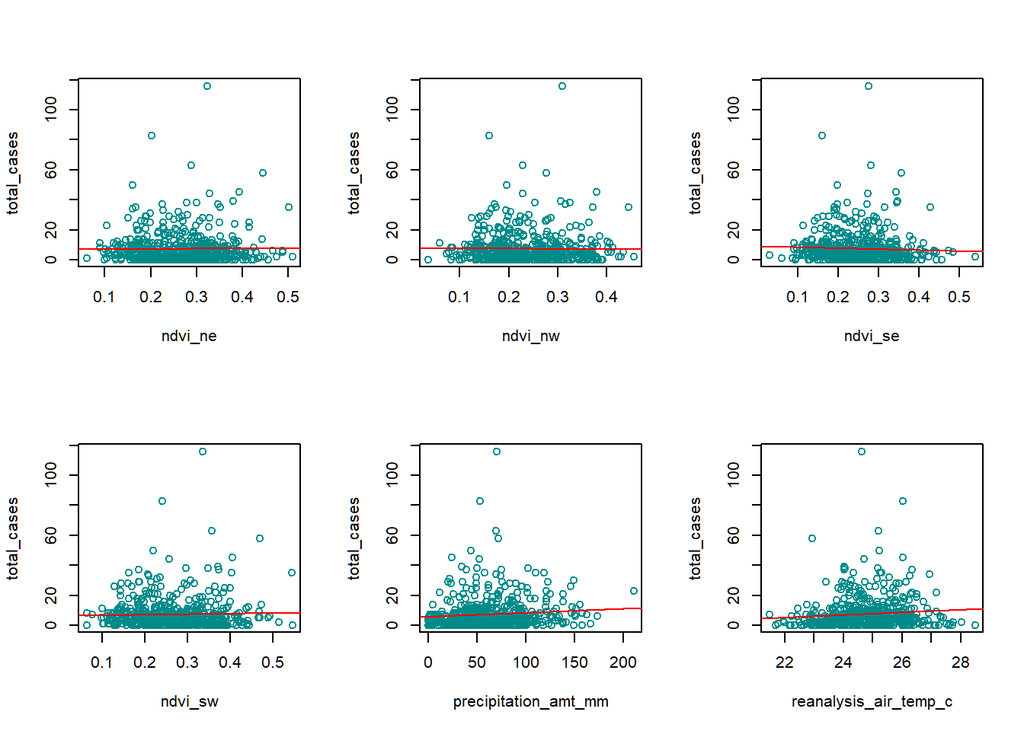

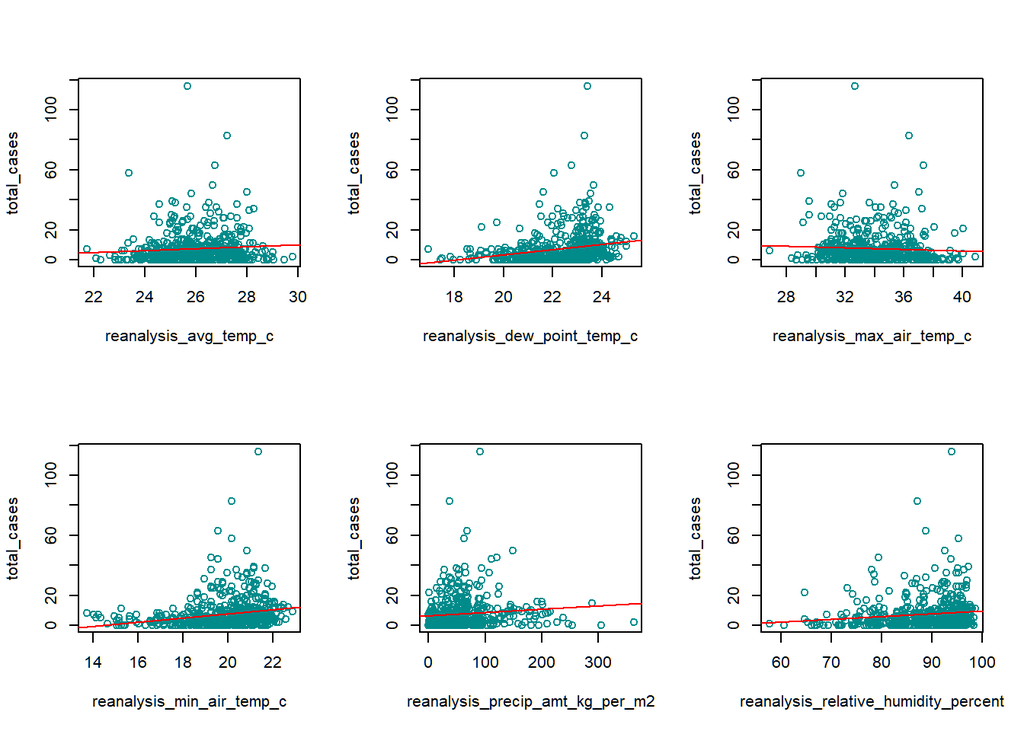

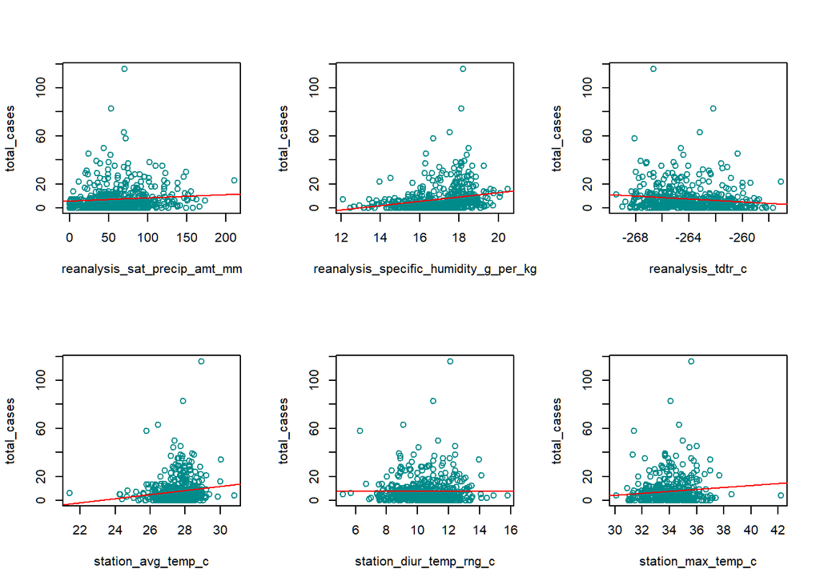

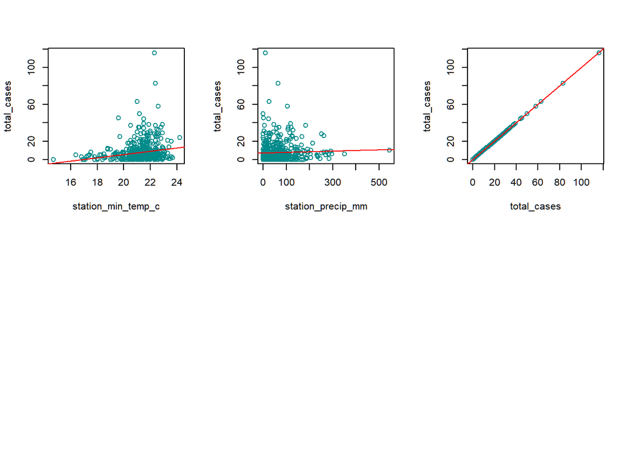

```r
par(mfrow=c(2,3))
for (i in c(5:25)) {plot(train_iq$total_cases ~ train_iq[,i], xlab = colnames(train_iq)[i], ylab = "total_cases", pch = 1, col = 'darkcyan')
abline(reg=lm(train_iq$total_cases ~ train_iq[,i]), col = 'red')}
```

Do the same for San Juan train set.

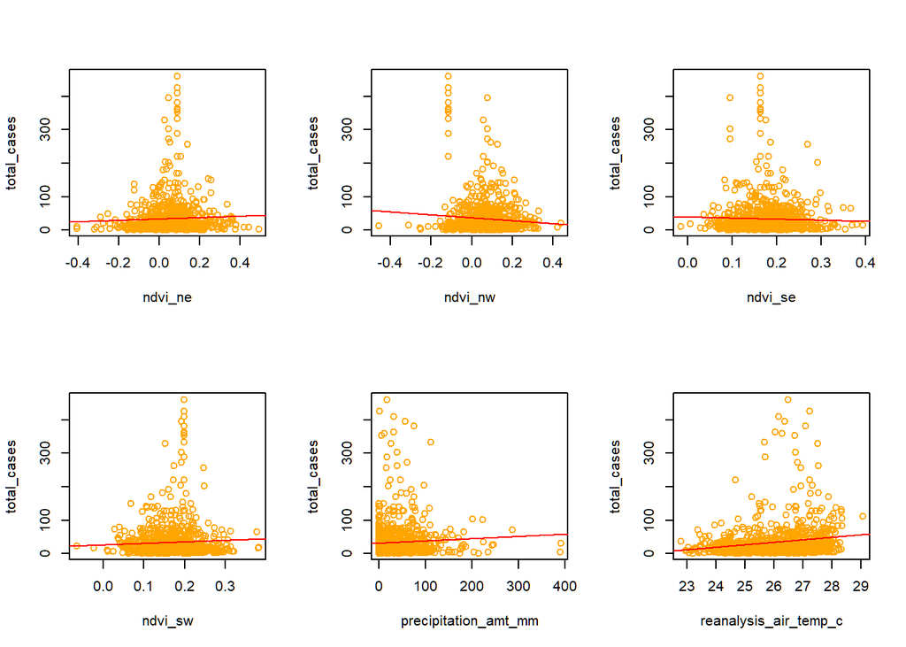

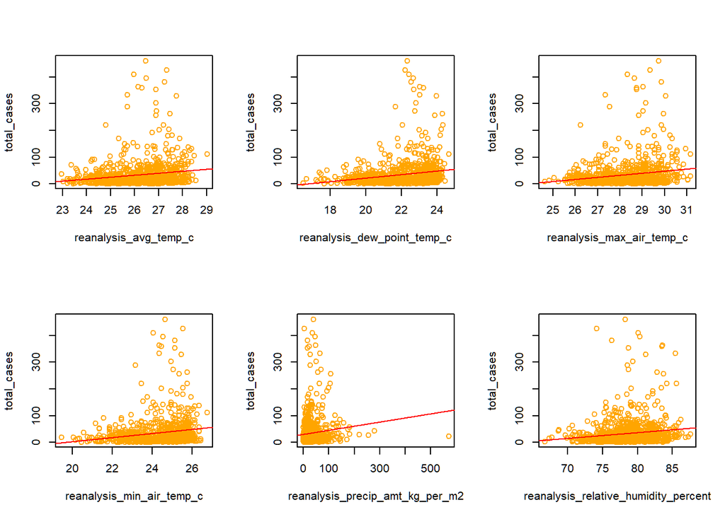

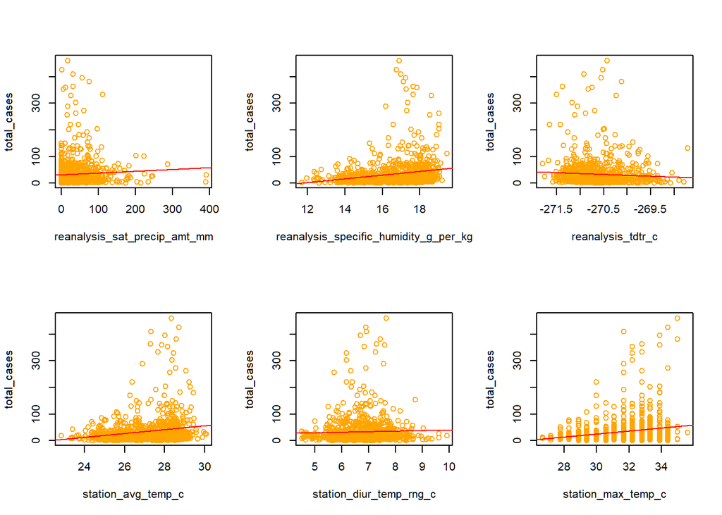

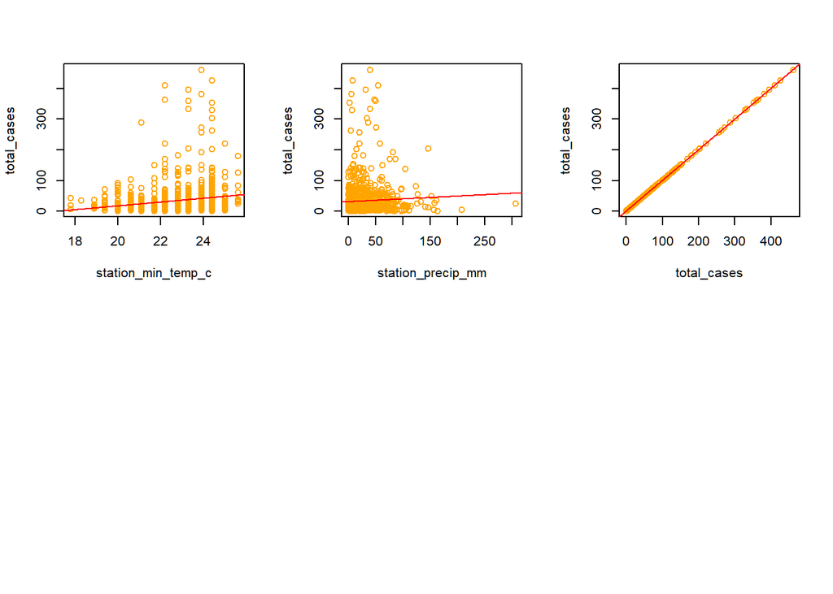

```r
par(mfrow=c(2,3))
for (i in c(5:25)) {plot(train_sj$total_cases ~ train_sj[,i], xlab = colnames(train_sj)[i], ylab = "total_cases", pch = 1, col = 'orange')
abline(reg=lm(train_sj$total_cases ~ train_sj[,i]), col = 'red')}
```

We split our training set by city, and plot the relationship of each climate variable against the response variable total_cases with a fitted line. Overall, each plot shows us very weak fits among the dependent variable; the data is very dispersed.